# R Notebook

In this homework we’ll use the msleep data set provided in the ggplot package. It concerns the sleeping patterns of various types of mammal.

```r
library(tidyverse)
library(infer)
sleep <- (msleep)
```

1.1 Jabberwockies sleep for around 7 hours a night, on average. Perform an appropriate statistical test to determine whether the mean sleep_total in the sampled population of animal types differs from the typical value for jabberwockies.

```r
observed_stat <- sleep %>%
  summarise(mean_sleep = mean(sleep_total))

observed_stat
```

| mean_sleep |
| --- |
| 10.43373 |

```r
null_distribution <- sleep %>%
  specify(response = sleep_total) %>%
  hypothesise(null = "point", mu = 7.0) %>%
  generate(reps = 10000, type = "bootstrap") %>%
  calculate(stat = "mean")

null_distribution
```

| replicate | stat |
| --- | --- |
| 1 | 7.031325 |
| 2 | 5.402410 |
| 3 | 7.046988 |
| 4 | 7.159036 |
| 5 | 6.883133 |
| 6 | 6.938554 |
| 7 | 6.731325 |
| 8 | 7.292771 |
| 9 | 6.832530 |
| 10 | 6.619277 |

[output cut: 990 more lines]

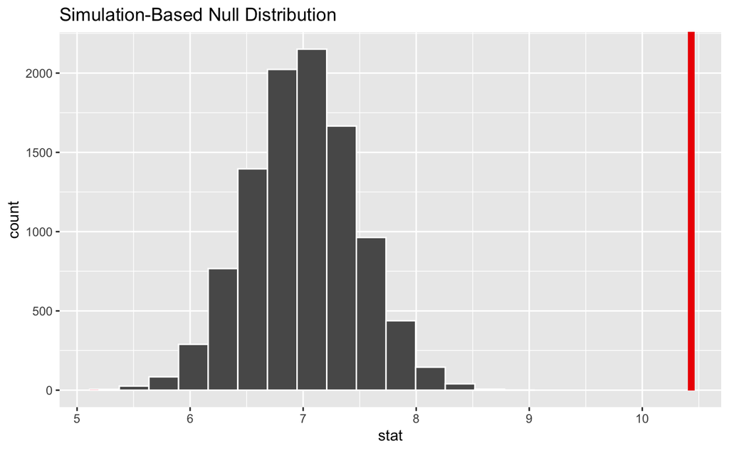

```r
null_distribution %>%
  visualise() +
  shade_p_value(obs_stat = observed_stat, direction = "both")
```

```r
p_value <- null_distribution %>%
  get_p_value(obs_stat = observed_stat, direction = "both")
```

```
Please be cautious in reporting a p-value of 0. This result is an approximation based on the number of `reps` chosen in the `generate()` step. See `?get_p_value()` for more information.
```

```r
p_value
```

| p_value |
| --- |
| 0 |

In this case we can reject our null hypothesis that jabberwockies and the animals in the sample sleep 7 hours a night. Our p value was under 0.05, indicating a statistically significant difference between the average amount of sleep between jabberwockies and animals in our sample.

1.2 Perform an appropriate statistical test to determine whether omnivores sleep for significantly longer than herbivores, on average.

```r
filtered_sleep <- sleep %>%
  filter(vore == "omni" | vore == "herbi")

filtered_sleep
```

| name | genus | vore | order | conservation | sleep_total | sleep_rem | sleep_cycle | awake | brainwt | bodywt |
| --- | --- | --- | --- | --- | --- | --- | --- | --- | --- | --- |
| Owl monkey | Aotus | omni | Primates | NA | 17.0 | 1.8 | NA | 7.0 | 0.01550 | 0.480 |
| Mountain beaver | Aplodontia | herbi | Rodentia | nt | 14.4 | 2.4 | NA | 9.6 | NA | 1.350 |
| Greater short-tailed shrew | Blarina | omni | Soricomorpha | lc | 14.9 | 2.3 | 0.1333333 | 9.1 | 0.00029 | 0.019 |
| Cow | Bos | herbi | Artiodactyla | domesticated | 4.0 | 0.7 | 0.6666667 | 20.0 | 0.42300 | 600.000 |
| Three-toed sloth | Bradypus | herbi | Pilosa | NA | 14.4 | 2.2 | 0.7666667 | 9.6 | NA | 3.850 |
| Roe deer | Capreolus | herbi | Artiodactyla | lc | 3.0 | NA | NA | 21.0 | 0.09820 | 14.800 |
| Goat | Capri | herbi | Artiodactyla | lc | 5.3 | 0.6 | NA | 18.7 | 0.11500 | 33.500 |
| Guinea pig | Cavis | herbi | Rodentia | domesticated | 9.4 | 0.8 | 0.2166667 | 14.6 | 0.00550 | 0.728 |
| Grivet | Cercopithecus | omni | Primates | lc | 10.0 | 0.7 | NA | 14.0 | NA | 4.750 |
| Chinchilla | Chinchilla | herbi | Rodentia | domesticated | 12.5 | 1.5 | 0.1166667 | 11.5 | 0.00640 | 0.420 |

[output cut: 42 more lines]

```r
filtered_sleep %>%
  group_by(vore, sleep_total) %>%
  summarise(sum = n()) %>%
  summarise(count = sum(sum))
```

| vore | count |
| --- | --- |
| herbi | 32 |
| omni | 20 |

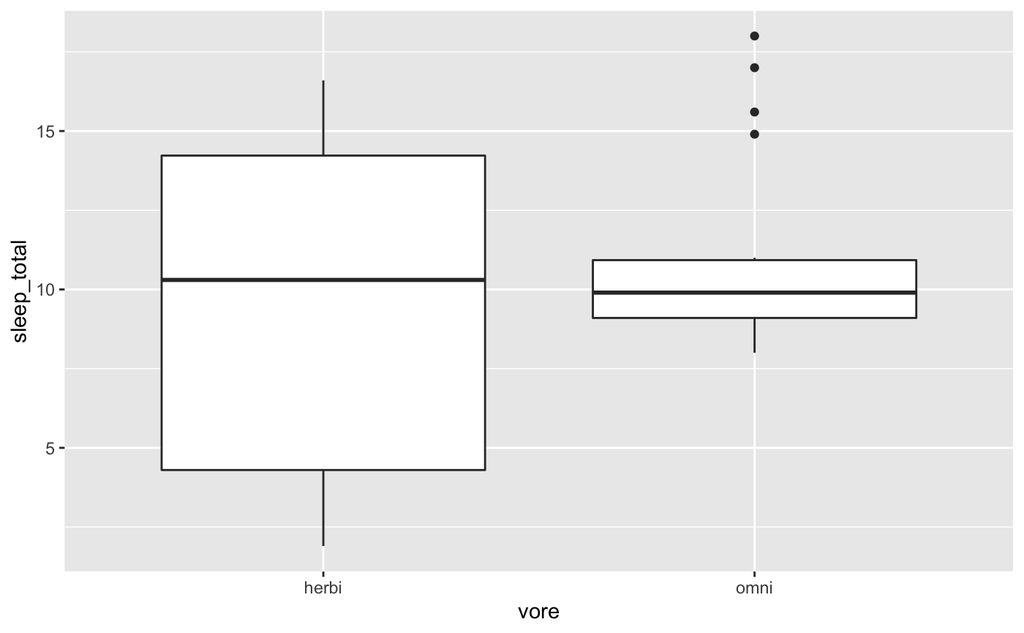

```r
filtered_sleep %>%
  ggplot(aes(sleep_total, vore)) +
  geom_boxplot() +
  coord_flip()
```

[output not shown]

[output not shown]

[output cut: 42 more lines]